# ML2 Project 1

Prateek Pagare

2025-04-1

## Problem 1: Binary Classification – has or has not used Marijuana

This section explores a binary classification tree to predict whether a respondent **has or has not used marijuana** (`MRJFLAG`). We use decision trees and pruning techniques to identify meaningful patterns in the data. The final result is evaluated using confusion matrices and error rates.

```r
# Load youth dataset
df <- read_excel("youth_data.xlsx")
head(df)
```

```
## # A tibble: 6 × 79
##   IRALCFY IRMJFY IRCIGFM IRSMKLSS30N IRALCFM IRMJFM IRCIGAGE IRSMKLSSTRY
##     <dbl>  <dbl>   <dbl>       <dbl>   <dbl>  <dbl>    <dbl>       <dbl>
## 1     991    991      91          91      91     91      991         991
## 2     991     60      91          91      91      2      991         991
## 3       1    991      91          91      93     91      991         991
## 4     991    991      91          91      91     91      991         991
## 5     991    991      91          91      91     91      991         991
## 6     991    991      91          91      91     91      991         991
## # ℹ 71 more variables: IRALCAGE <dbl>, IRMJAGE <dbl>, MRJFLAG <dbl>,
## #   ALCFLAG <dbl>, TOBFLAG <dbl>, ALCYDAYS <dbl>, MRJYDAYS <dbl>,
## #   ALCMDAYS <dbl>, MRJMDAYS <dbl>, CIGMDAYS <dbl>, SMKLSMDAYS <dbl>,
## #   SCHFELT <dbl>, TCHGJOB <dbl>, AVGGRADE <dbl>, STNDSCIG <dbl>,
## #   STNDSMJ <dbl>, STNDALC <dbl>, STNDDNK <dbl>, PARCHKHW <dbl>,
## #   PARHLPHW <dbl>, PRCHORE2 <dbl>, PRLMTTV2 <dbl>, PARLMTSN <dbl>,
## #   PRGDJOB2 <dbl>, PRPROUD2 <dbl>, ARGUPAR <dbl>, YOFIGHT2 <dbl>, …
```

```r
summary(df)
```

```
##     IRALCFY          IRMJFY         IRCIGFM       IRSMKLSS30N
##  Min.   :  1.0   Min.   :  1.0   Min.   : 1.00   Min.   : 1.00
##  1st Qu.:991.0   1st Qu.:991.0   1st Qu.:91.00   1st Qu.:91.00
##  Median :991.0   Median :991.0   Median :91.00   Median :91.00
##  Mean   :820.1   Mean   :876.9   Mean   :89.94   Mean   :90.78
##  3rd Qu.:991.0   3rd Qu.:991.0   3rd Qu.:91.00   3rd Qu.:91.00
##  Max.   :993.0   Max.   :993.0   Max.   :93.00   Max.   :93.00
##
##     IRALCFM          IRMJFM         IRCIGAGE      IRSMKLSSTRY
##  Min.   : 1.00   Min.   : 1.00   Min.   :  1.0   Min.   :  7.0
##  1st Qu.:91.00   1st Qu.:91.00   1st Qu.:991.0   1st Qu.:991.0
##  Median :91.00   Median :91.00   Median :991.0   Median :991.0
##  Mean   :85.21   Mean   :85.49   Mean   :920.1   Mean   :976.1
##  3rd Qu.:91.00   3rd Qu.:91.00   3rd Qu.:991.0   3rd Qu.:991.0
##  Max.   :93.00   Max.   :93.00   Max.   :991.0   Max.   :991.0
##
##     IRALCAGE        IRMJAGE         MRJFLAG          ALCFLAG
##  Min.   :  1.0   Min.   :  4.0   Min.   :0.0000   Min.   :0.0000
##  1st Qu.:991.0   1st Qu.:991.0   1st Qu.:0.0000   1st Qu.:0.0000
##  Median :991.0   Median :991.0   Median :0.0000   Median :0.0000
##  Mean   :768.5   Mean   :843.9   Mean   :0.1506   Mean   :0.2276
##  3rd Qu.:991.0   3rd Qu.:991.0   3rd Qu.:0.0000   3rd Qu.:0.0000
##  Max.   :991.0   Max.   :991.0   Max.   :1.0000   Max.   :1.0000
##
##     TOBFLAG           ALCYDAYS        MRJYDAYS        ALCMDAYS
##  Min.   :0.00000   Min.   :1.000   Min.   :1.000   Min.   :1.000
##  1st Qu.:0.00000   1st Qu.:6.000   1st Qu.:6.000   1st Qu.:5.000
##  Median :0.00000   Median :6.000   Median :6.000   Median :5.000
##  Mean   :0.09071   Mean   :5.224   Mean   :5.557   Mean   :4.756
##  3rd Qu.:0.00000   3rd Qu.:6.000   3rd Qu.:6.000   3rd Qu.:5.000
##  Max.   :1.00000   Max.   :6.000   Max.   :6.000   Max.   :5.000
##
##     MRJMDAYS        CIGMDAYS       SMKLSMDAYS       SCHFELT
##  Min.   :1.000   Min.   :1.000   Min.   :1.000   Min.   :1.000
##  1st Qu.:5.000   1st Qu.:6.000   1st Qu.:5.000   1st Qu.:1.000
##  Median :5.000   Median :6.000   Median :5.000   Median :1.000
##  Mean   :4.826   Mean   :5.943   Mean   :4.992   Mean   :1.291
##  3rd Qu.:5.000   3rd Qu.:6.000   3rd Qu.:5.000   3rd Qu.:2.000
##  Max.   :5.000   Max.   :6.000   Max.   :5.000   Max.   :2.000
##
```

[output cut: 89 more lines]

```
##  Min.   :1.000   Min.   :1.000   Min.   :1.000   Min.   :1.000
##  1st Qu.:1.000   1st Qu.:1.000   1st Qu.:2.000   1st Qu.:1.000
##  Median :1.000   Median :1.000   Median :3.000   Median :2.000
##  Mean   :1.095   Mean   :1.295   Mean   :2.938   Mean   :1.704
##  3rd Qu.:1.000   3rd Qu.:2.000   3rd Qu.:4.000   3rd Qu.:2.000
##  Max.   :3.000   Max.   :3.000   Max.   :4.000   Max.   :2.000
##
##     POVERTY3         PDEN10         COUTYP4
##  Min.   :1.000   Min.   :1.000   Min.   :1.00
##  1st Qu.:2.000   1st Qu.:1.000   1st Qu.:1.00
##  Median :3.000   Median :2.000   Median :2.00
##  Mean   :2.322   Mean   :1.619   Mean   :1.69
##  3rd Qu.:3.000   3rd Qu.:2.000   3rd Qu.:2.00
##  Max.   :3.000   Max.   :3.000   Max.   :3.00
##
```

To model whether a youth respondent has ever used marijuana (MRJFLAG), we first created a filtered version of the dataset that removes any variables directly tied to substance use, such as usage frequency or age of first use. This ensures we’re not accidentally “leaking” information from the target variable into our predictors

The response variable MRJFLAG  
- 0: Has never used marijuana  
- 1: Has ever used marijuana

```r
# Prepare data by removing drug use predictors to avoid leakage
mari_bin <- df %>%select(-IRMJFY, -IRMJAGE, -MRJYDAYS, -MRJMDAYS, -IRALCFY, -IRCIGFM, -IRSMKLSS30N,-IRALCFM, -IRMJFM, -IRCIGAGE, -IRSMKLSSTRY, -IRALCAGE, -ALCFLAG, -TOBFLAG,-ALCYDAYS, -ALCMDAYS, -CIGMDAYS, -SMKLSMDAYS) %>% mutate(MRJFLAG = as.factor(MRJFLAG)) %>%
drop_na(MRJFLAG)     #reference:https://www.spsanderson.com/steveondata/posts/2024-11-26/#:~:text=The%20select()%20function%20from%20the%20dplyr%20package%20provides%20a,specifying%20their%20names%20or%20indices.
head(mari_bin)
```

```
## # A tibble: 6 × 61
##   MRJFLAG SCHFELT TCHGJOB AVGGRADE STNDSCIG STNDSMJ STNDALC STNDDNK PARCHKHW
##   <fct>     <dbl>   <dbl>    <dbl>    <dbl>   <dbl>   <dbl>   <dbl>    <dbl>
## 1 0             1       1        2        2       2       2       2        1
## 2 1             2       1        2        1       1       1       1        1
## 3 0             1       1        2        2       2       2       2        1
## 4 0             2       1       NA        2       2       2       2        1
## 5 0             1       2        2        2       2       2       2        2
## 6 0             1       1        2        2       2       2       2        1
## # ℹ 52 more variables: PARHLPHW <dbl>, PRCHORE2 <dbl>, PRLMTTV2 <dbl>,
## #   PARLMTSN <dbl>, PRGDJOB2 <dbl>, PRPROUD2 <dbl>, ARGUPAR <dbl>,
## #   YOFIGHT2 <dbl>, YOGRPFT2 <dbl>, YOHGUN2 <dbl>, YOSELL2 <dbl>,
## #   YOSTOLE2 <dbl>, YOATTAK2 <dbl>, PRPKCIG2 <dbl>, PRMJEVR2 <dbl>,
## #   PRMJMO <dbl>, PRALDLY2 <dbl>, YFLPKCG2 <dbl>, YFLTMRJ2 <dbl>,
## #   YFLMJMO <dbl>, YFLADLY2 <dbl>, FRDPCIG2 <dbl>, FRDMEVR2 <dbl>,
## #   FRDMJMON <dbl>, FRDADLY2 <dbl>, TALKPROB <dbl>, PRTALK3 <dbl>, …
```

```r
set.seed(1236)
train_index <- sample(1:nrow(mari_bin), floor(0.7 * nrow(mari_bin)))
train <- mari_bin[train_index, ]
test <- mari_bin[-train_index, ]
dim(train)
```

```
## [1] 7392   61
```

```r
dim(test)
```

```
## [1] 3169   61
```

```r
summary(df$MRJFLAG)
```

```
##    Min. 1st Qu.  Median    Mean 3rd Qu.    Max.
##  0.0000  0.0000  0.0000  0.1506  0.0000  1.0000
```

```r
table(mari_bin$MRJFLAG)
```

```
##
##    0    1
## 8971 1590
```

This shows that only ~15% of youth in our data reported ever using marijuana. The dataset is imbalanced, which means our model could lean toward predicting “0” more often unless properly adjusted.then  
To train and evaluate the model, we split the dataset into 70% training and 30% testing sets.

### Train a classification tree and evaluate

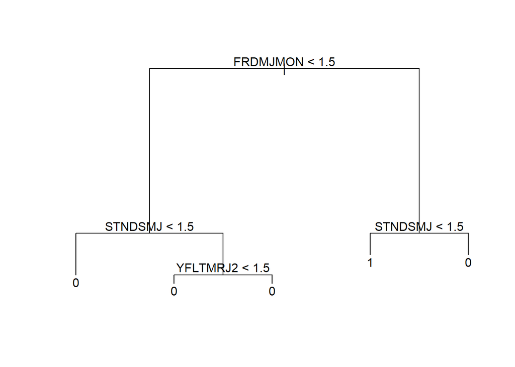

```r
tree_model <- tree(MRJFLAG ~ ., data = train)
plot(tree_model)
text(tree_model, pretty = 0)
```

```r
pred <- predict(tree_model, test, type = "class")
conf_mat <- table(Predicted = pred, Actual = test$MRJFLAG)
print(conf_mat)
```

```
##          Actual
## Predicted    0    1
##         0 2564  248
##         1  139  218
```

```r
cat("Test Accuracy:", round(mean(pred == test$MRJFLAG) * 100, 2), "%\n")
```

```
## Test Accuracy: 87.79 %
```

The classification tree’s top split variable is FRDMJMON, which captures peer disapproval toward marijuana use. Youths who reported their close friends disapprove (i.e., FRDMJMON = 1) were significantly more likely to have never used marijuana.

Further splits such as STNDSMJ (perception of other students using marijuana) and YFLTMRJ2 (how the youth feels about peer marijuana initiation) reinforce the role of social norms in shaping behavior.  
The final key variable, YFLTMRJ2, measures how the youth personally feels about peers trying marijuana. Values below 1.5 mean they disapprove, which again aligns with lower likelihood of personal use. and also

and accuracy 87.79 % , indicates that the model performs fairly well, correctly predicting nearly 88% of the test cases. However, there is some imbalance in prediction performance — it tends to be more conservative.

### Cross-validation and pruning

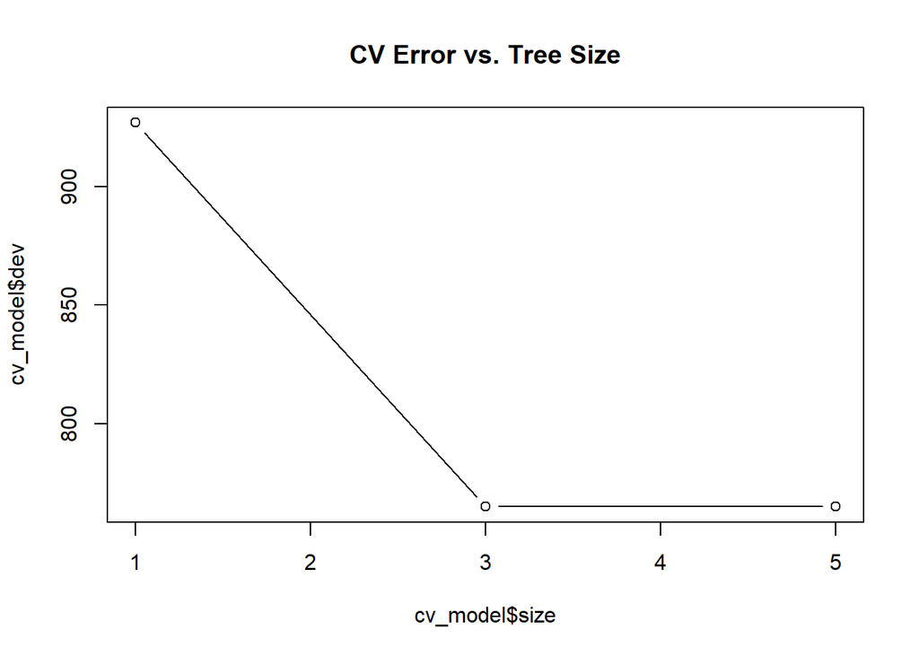

```r
cv_model <- cv.tree(tree_model, FUN = prune.misclass)
plot(cv_model$size, cv_model$dev, type = "b", main = "CV Error vs. Tree Size")
```

```r
opt_size <- cv_model$size[which.min(cv_model$dev)]
pruned_model <- prune.misclass(tree_model, best = opt_size)
pruned_model
```

```
## node), split, n, deviance, yval, (yprob)
##       * denotes terminal node
##
##  1) root 5781 5090.0 0 ( 0.83965 0.16035 )
##    2) FRDMJMON < 1.5 4463 2204.0 0 ( 0.93256 0.06744 )
##      4) STNDSMJ < 1.5 919  928.5 0 ( 0.79652 0.20348 ) *
##      5) STNDSMJ > 1.5 3544 1008.0 0 ( 0.96783 0.03217 )
##       10) YFLTMRJ2 < 1.5 3262  736.5 0 ( 0.97609 0.02391 ) *
##       11) YFLTMRJ2 > 1.5 282  215.4 0 ( 0.87234 0.12766 ) *
##    3) FRDMJMON > 1.5 1318 1824.0 0 ( 0.52504 0.47496 )
##      6) STNDSMJ < 1.5 771 1031.0 1 ( 0.39040 0.60960 ) *
##      7) STNDSMJ > 1.5 547  654.0 0 ( 0.71481 0.28519 ) *
```

```r
summary(pruned_model)
```

```
##
## Classification tree:
## tree(formula = MRJFLAG ~ ., data = train)
## Variables actually used in tree construction:
## [1] "FRDMJMON" "STNDSMJ"  "YFLTMRJ2"
## Number of terminal nodes:  5
## Residual mean deviance:  0.6174 = 3566 / 5776
## Misclassification error rate: 0.1311 = 758 / 5781
```

Using cross-validation for misclassification pruning, the optimal tree size was found to be 5 nodes. Interestingly, both the pruned and unpruned trees gave the same performance on both training and test sets — suggesting that the original tree already had good generalization without overfitting.

### Compare errors

```r
train_pred_unpruned <- predict(tree_model, newdata = train, type = "class")
train_pred_pruned <- predict(pruned_model, newdata = train, type = "class")
train_error_unpruned <- mean(train_pred_unpruned != train$MRJFLAG)
train_error_pruned <- mean(train_pred_pruned != train$MRJFLAG)
cat("unpruned train error:", round(train_error_unpruned * 100, 2), "%\n")
```

```
## unpruned train error: 12.46 %
```

```r
cat("pruned train error:", round(train_error_pruned * 100, 2), "%\n")
```

```
## pruned train error: 12.46 %
```

```r
pruned_pred <- predict(pruned_model, test, type = "class")
cat("Unpruned test error :", round(mean(pred != test$MRJFLAG) * 100, 2), "%\n")
```

```
## Unpruned test error : 12.21 %
```

```r
cat("Pruned test error :", round(mean(pruned_pred != test$MRJFLAG) * 100, 2),"%\n")
```

```
## Pruned test error : 12.21 %
```

```r
opt_size <- cv_model$size[which.min(cv_model$dev)]
cat("Optimal Tree Size:", opt_size)
```

```
## Optimal Tree Size: 5
```

pruning the tree didn’t change the error rates — both the unpruned and pruned trees performed identically on training and test sets. This suggests the original tree was already quite balanced and not overfitting the data.

## Problem 2: Multi-class Classification – Monthly Marijuana Frequency

This part uses decision trees and ensemble models to classify marijuana use in the past month into three categories: `Seldom`, `Sometimes`, and `Frequent`.and To align with project expectations and avoid data leakage, we carefully removed all variables directly linked to drug usage frequency (such as IRMJFY, IRALCFY, MRJFLAG, etc.). The remaining variables reflect demographic and behavioral traits that could help explain youth substance behavior without circular reasoning.

```r
mari_multi <- df %>%mutate(MRJMDAYS = case_when(MRJMDAYS == 1 ~ "Seldom",MRJMDAYS == 2 ~ "Sometimes",MRJMDAYS %in% c(3,4) ~ "Frequent",MRJMDAYS == 5 ~ NA_character_)) %>%drop_na(MRJMDAYS) %>%
mutate(MRJMDAYS = factor(MRJMDAYS, levels = c("Seldom", "Sometimes", "Frequent"))) %>%
  select(MRJMDAYS, everything(),-MRJFLAG, -IRMJFY, -IRMJAGE, -MRJYDAYS, -IRALCFY, -IRCIGFM,-IRSMKLSS30N, -IRALCFM, -IRMJFM, -IRCIGAGE, -IRSMKLSSTRY, -IRALCAGE,-ALCFLAG, -TOBFLAG, -ALCYDAYS, -ALCMDAYS, -CIGMDAYS, -SMKLSMDAYS) %>% mutate(across(everything(), ~replace_na(., 0))) #reference: https://dplyr.tidyverse.org/reference/mutate.html
mari_multi
```

```
## # A tibble: 752 × 61
##    MRJMDAYS  SCHFELT TCHGJOB AVGGRADE STNDSCIG STNDSMJ STNDALC STNDDNK PARCHKHW
##    <fct>       <dbl>   <dbl>    <dbl>    <dbl>   <dbl>   <dbl>   <dbl>    <dbl>
##  1 Seldom          2       1        2        1       1       1       1        1
##  2 Sometimes       2       2        2        1       2       2       1        2
##  3 Frequent        1       1        2        2       1       1       2        1
##  4 Frequent        2       2        1        2       1       1       1        2
##  5 Frequent        2       2        1        2       2       2       2        1
##  6 Sometimes       2       1        2        2       1       1       1        1
##  7 Seldom          2       2        2        2       1       1       1        2
##  8 Seldom          1       1        2        2       1       2       2        1
##  9 Frequent        2       1        1        2       2       2       2        2
## 10 Frequent        1       2        2        2       2       1       2        2
## # ℹ 742 more rows
## # ℹ 52 more variables: PARHLPHW <dbl>, PRCHORE2 <dbl>, PRLMTTV2 <dbl>,
## #   PARLMTSN <dbl>, PRGDJOB2 <dbl>, PRPROUD2 <dbl>, ARGUPAR <dbl>,
## #   YOFIGHT2 <dbl>, YOGRPFT2 <dbl>, YOHGUN2 <dbl>, YOSELL2 <dbl>,
## #   YOSTOLE2 <dbl>, YOATTAK2 <dbl>, PRPKCIG2 <dbl>, PRMJEVR2 <dbl>,
## #   PRMJMO <dbl>, PRALDLY2 <dbl>, YFLPKCG2 <dbl>, YFLTMRJ2 <dbl>,
## #   YFLMJMO <dbl>, YFLADLY2 <dbl>, FRDPCIG2 <dbl>, FRDMEVR2 <dbl>, …
```

```r
summary(mari_multi$MRJMDAYS)
```

```
##    Seldom Sometimes  Frequent
##       195       149       408
```

```r
#Data into Training and Test Sets
set.seed(2025)
ind <- sample(1:nrow(mari_multi), floor(0.7 * nrow(mari_multi)))
train <- mari_multi[ind, ]
test <- mari_multi[-ind, ]
dim(train)
```

```
## [1] 526  61
```

```r
dim(test)
```

```
## [1] 226  61
```

In this, we use predicting the frequency of marijuana use in the past month, categorized into three intuitive classes:

- Seldom (1–2 days)
- Sometimes (3–5 days)
- Frequent (6–30 days)

After cleaning and transforming the data:\ Total Records (before split): 752  
Training Set: 526 observations  
Test Set: 226 observations  
Target Variable: MRJMDAYS (3-class factor)

### Fit a Multiclass Classification Tree

```r
multi_tree <- tree(MRJMDAYS ~ ., data = train)
summary(multi_tree)
```

```
##
## Classification tree:
## tree(formula = MRJMDAYS ~ ., data = train)
## Variables actually used in tree construction:
## [1] "EDUSKPCOM" "PRVDRGO2"  "PRALDLY2"  "ARGUPAR"   "FRDMEVR2"
## Number of terminal nodes:  6
## Residual mean deviance:  1.864 = 969.3 / 520
## Misclassification error rate: 0.4183 = 220 / 526
```

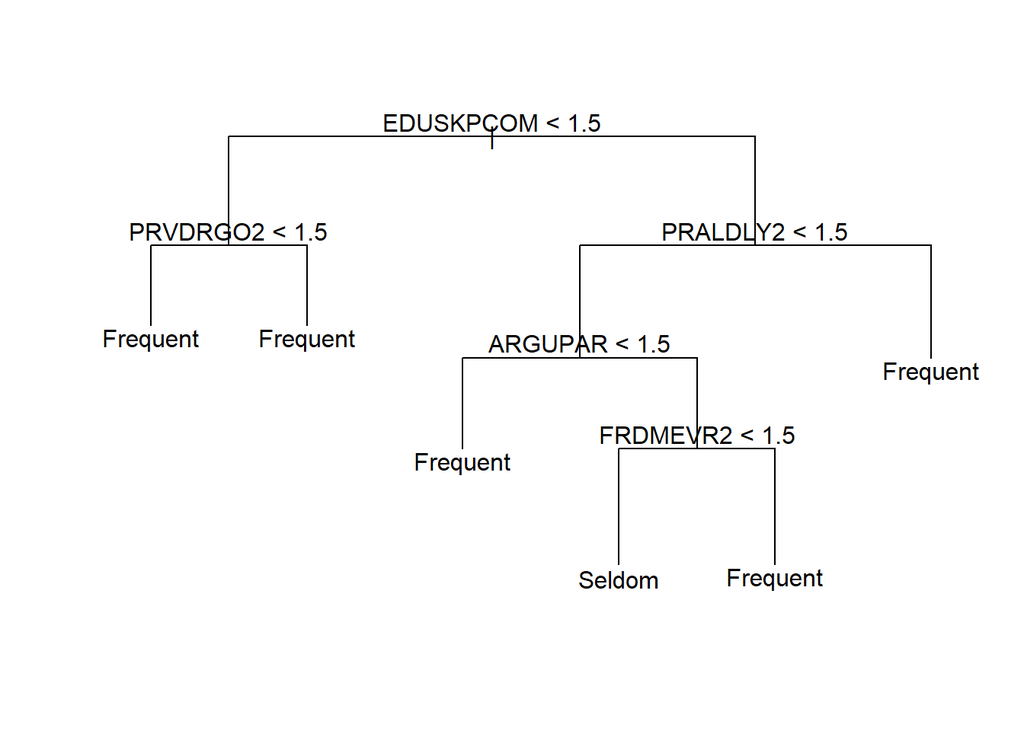

```r
plot(multi_tree)
text(multi_tree, pretty = 0)
```

```r
test_pred <- predict(multi_tree, newdata = test, type = "class")
conf_mat <- table(Predicted = test_pred, Actual = test$MRJMDAYS)
conf_mat
```

```
##            Actual
## Predicted   Seldom Sometimes Frequent
##   Seldom         2         2        1
##   Sometimes      0         0        0
##   Frequent      60        49      112
```

```r
cat("Test Error (Tree):", round(mean(test_pred != test$MRJMDAYS) * 100, 2), "%\n")
```

```
## Test Error (Tree): 49.56 %
```

In this section, we applied a classification tree to predict marijuana use frequency during the past month, categorized as Seldom, Sometimes, and Frequent.

Other predictors such as PRALDLY2 (perceived parental disapproval) and FRDMEVR2 (friends’ attitude) consistently split nodes, matching the worksheet’s emphasis on parental and peer influence.

## Fit a Bagged Model

```r
bag_model <- randomForest(MRJMDAYS ~ ., data = train, mtry = 40, importance = TRUE)
bag_model
```

```
##
## Call:
##  randomForest(formula = MRJMDAYS ~ ., data = train, mtry = 40,      importance = TRUE)
##                Type of random forest: classification
##                      Number of trees: 500
## No. of variables tried at each split: 40
##
##         OOB estimate of  error rate: 45.06%
## Confusion matrix:
##           Seldom Sometimes Frequent class.error
## Seldom        24         4      105   0.8195489
## Sometimes     15         0       83   1.0000000
## Frequent      24         6      265   0.1016949
```

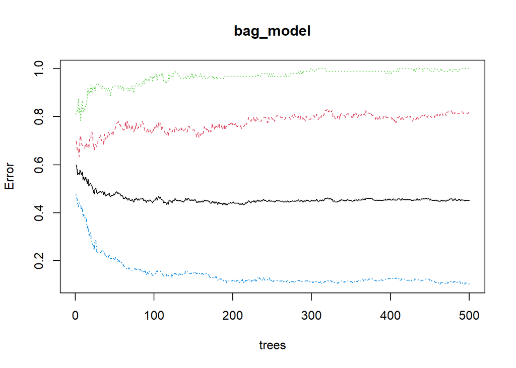

```r
plot(bag_model)
```

## Predict and Evaluate Bagged Model on test data

```r
bag_pred <- predict(bag_model, newdata = test, type = "class")
bag_conf <- table(Predicted = bag_pred, Actual = test$MRJMDAYS)
bag_conf
```

```
##            Actual
## Predicted   Seldom Sometimes Frequent
##   Seldom        12        11       12
##   Sometimes      2         0        1
##   Frequent      48        40      100
```

```r
bag_error <- mean(bag_pred != test$MRJMDAYS)
cat("bagging test err :", round(bag_error * 100, 2), "%\n")
```

```
## bagging test err : 50.44 %
```

###Random Forest Model

```r
rf_model <- randomForest(MRJMDAYS ~ ., data = train, importance = TRUE)
rf_model
```

```
##
## Call:
##  randomForest(formula = MRJMDAYS ~ ., data = train, importance = TRUE)
##                Type of random forest: classification
##                      Number of trees: 500
## No. of variables tried at each split: 7
##
##         OOB estimate of  error rate: 43.92%
## Confusion matrix:
##           Seldom Sometimes Frequent class.error
## Seldom        19         3      111  0.85714286
## Sometimes     11         1       86  0.98979592
## Frequent      17         3      275  0.06779661
```

```r
rf_pred <- predict(rf_model, newdata = test)
rf_conf <- table(Predicted = rf_pred, Actual = test$MRJMDAYS)
rf_conf
```

```
##            Actual
## Predicted   Seldom Sometimes Frequent
##   Seldom        12         8        4
##   Sometimes      0         0        1
##   Frequent      50        43      108
```

```r
cat("RandomForest test error:", round(mean(rf_pred != test$MRJMDAYS) * 100, 2), "%\n")
```

```
## RandomForest test error: 46.9 %
```

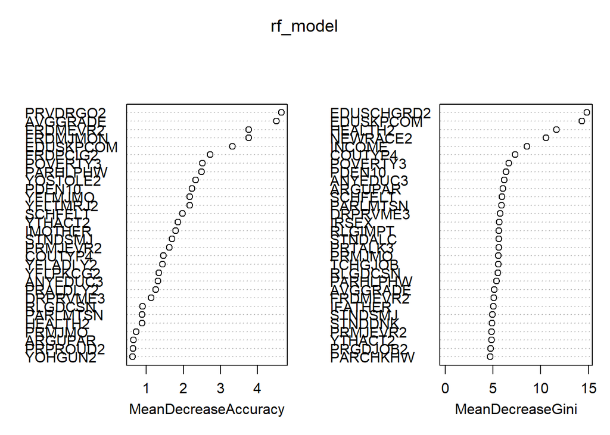

```r
varImpPlot(rf_model)
```

## Problem 3: Regression – Days of Marijuana Use in Past Year

```r
mari_regress <- df %>%filter(IRMJFY >= 1 & IRMJFY <= 365) %>%select(IRMJFY, everything(),-MRJFLAG, -IRMJAGE, -MRJYDAYS,-IRALCFY, -MRJMDAYS,-IRCIGFM, -IRSMKLSS30N, -IRALCFM, -IRMJFM,-IRCIGAGE, -IRSMKLSSTRY, -IRALCAGE, -ALCFLAG, -TOBFLAG,-ALCYDAYS, -ALCMDAYS, -CIGMDAYS, -SMKLSMDAYS) %>% mutate(across(everything(), ~replace_na(., 0)))
mari_regress
```

```
## # A tibble: 1,335 × 61
##    IRMJFY SCHFELT TCHGJOB AVGGRADE STNDSCIG STNDSMJ STNDALC STNDDNK PARCHKHW
##     <dbl>   <dbl>   <dbl>    <dbl>    <dbl>   <dbl>   <dbl>   <dbl>    <dbl>
##  1     60       2       1        2        1       1       1       1        1
##  2     10       2       2        2        1       2       2       1        2
##  3    168       1       1        2        2       1       1       2        1
##  4    364       2       2        1        2       1       1       1        2
##  5    240       2       2        1        2       2       2       2        1
##  6      8       2       1        2        1       1       2       2        1
##  7     10       2       1        2        2       1       1       1        1
##  8     36       2       2        2        2       1       1       1        2
##  9      2       1       1        2        2       1       2       2        1
## 10    150       1       1        2        1       1       1       2        1
## # ℹ 1,325 more rows
## # ℹ 52 more variables: PARHLPHW <dbl>, PRCHORE2 <dbl>, PRLMTTV2 <dbl>,
## #   PARLMTSN <dbl>, PRGDJOB2 <dbl>, PRPROUD2 <dbl>, ARGUPAR <dbl>,
## #   YOFIGHT2 <dbl>, YOGRPFT2 <dbl>, YOHGUN2 <dbl>, YOSELL2 <dbl>,
## #   YOSTOLE2 <dbl>, YOATTAK2 <dbl>, PRPKCIG2 <dbl>, PRMJEVR2 <dbl>,
## #   PRMJMO <dbl>, PRALDLY2 <dbl>, YFLPKCG2 <dbl>, YFLTMRJ2 <dbl>,
## #   YFLMJMO <dbl>, YFLADLY2 <dbl>, FRDPCIG2 <dbl>, FRDMEVR2 <dbl>, …
```

```r
set.seed(1234)
train_ind <- sample(1:nrow(mari_regress), floor(0.7 * nrow(mari_regress)))
train <- mari_regress[train_ind, ]
test <- mari_regress[-train_ind, ]
dim(train)
```

```
## [1] 934  61
```

```r
dim(test)
```

```
## [1] 401  61
```

For this regression task, we predicted IRMJFY — the number of days a respondent used marijuana in the past year (ranging from 1 to 365).first did filtered out invalid or imputed values also filled all remaining NA’s with 0 to ensure a clean input for tree-based models.then split the data  
-Training set: 934 records  
-Test set: 401 records

### Regression Tree and Evaluation

```r
reg_tree <- tree(IRMJFY ~ ., data = train)
summary(reg_tree)
```

```
##
## Regression tree:
## tree(formula = IRMJFY ~ ., data = train)
## Variables actually used in tree construction:
## [1] "YOSELL2"   "EDUSKPCOM" "PRMJMO"    "YOGRPFT2"  "ARGUPAR"
## Number of terminal nodes:  6
## Residual mean deviance:  10870 = 10090000 / 928
## Distribution of residuals:
##    Min. 1st Qu.  Median    Mean 3rd Qu.    Max.
## -234.70  -55.82  -42.79    0.00   51.99  308.20
```

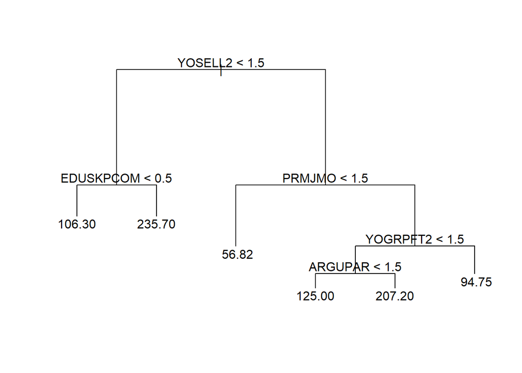

```r
plot(reg_tree)
text(reg_tree, pretty = 0)
```

```r
reg_pred <- predict(reg_tree, newdata = test)
reg_mse <- mean((test$IRMJFY - reg_pred)^2)
cat("unpruned Test MSE :", round(reg_mse, 2), "\n")
```

```
## unpruned Test MSE : 10280.03
```

The regression tree’s root node split on YOSELL2 (whether the youth reported ever selling illegal drugs). This reflects a risk clustering effect, consistent with what we observed in the Carseats example — where predictors like price and shelf location identified target behavior.

Additional splits such as EDUSKPCOM (school skipping), PRMJMO (parental views on monthly marijuana), and ARGUPAR (family conflict) further differentiated high-usage youth, reinforcing the multi-domain impact (peer, school, family) seen in the codebook’s “Youth Experiences” section.

### Cross-validation and Pruning

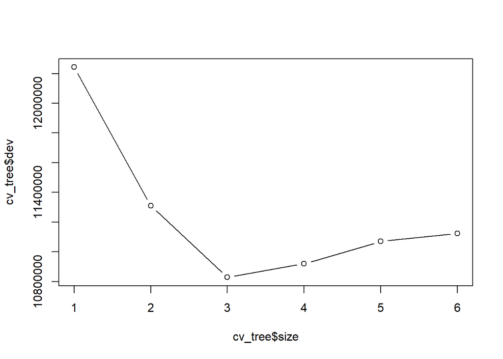

```r
cv_tree <- cv.tree(reg_tree)
plot(cv_tree$size, cv_tree$dev, type = "b")
```

```r
best_size <- cv_tree$size[which.min(cv_tree$dev)]
reg_pruned <- prune.tree(reg_tree, best = best_size)
pruned_pred <- predict(reg_pruned, newdata = test)
pruned_mse <- mean((test$IRMJFY - pruned_pred)^2)
cat("pruned test MSE:", round(pruned_mse, 2), "\n")
```

```
## pruned test MSE: 10157.17
```

To avoid overfitting, we used cross-validation to select the optimal tree size. The plot shows the test deviance decreasing sharply until a tree size of 3, The optimal tree size chosen was 3, balancing model complexity and performance.The pruned tree’s test MSE improved slightly to 10,157.17, compared to 10,280.03 for the unpruned tree.

### Random Forest with Tuning

```r
rf_model <- randomForest(IRMJFY ~ ., data = train, importance = TRUE)
rf_pred <- predict(rf_model, newdata = test)
rf_mse <- mean((rf_pred - test$IRMJFY)^2)
cat("RandForest test MSE:", round(rf_mse, 2), "\n")
```

```
## RandForest test MSE: 9671.08
```

```r
# different mtry
mtry_vals <- c(5, 10, 15, 20, 30)
mse_results <- map_dbl(mtry_vals, ~{model <- randomForest(IRMJFY ~ ., data = train, mtry = .x)
pred <- predict(model, test)
mean((test$IRMJFY - pred)^2)})
data.frame(mtry = mtry_vals, MSE = round(mse_results, 2)) #reference https://www.w3schools.com/r/r_data_frames.asp
```

```
##   mtry     MSE
## 1    5 9479.69
## 2   10 9480.99
## 3   15 9661.61
## 4   20 9715.35
## 5   30 9799.91
```

## Variable Importance Plot

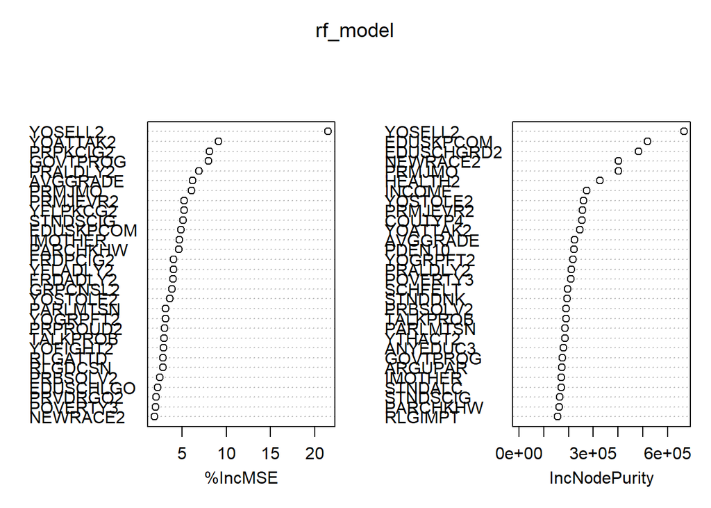

```r
varImpPlot(rf_model)
```

```r
cat("Model MSE Comparison:\n")
```

```
## Model MSE Comparison:
```

```r
cat("Unpruned Tree:", round(reg_mse, 2), "\n")
```

```
## Unpruned Tree: 10280.03
```

```r
cat("Pruned Tree:", round(pruned_mse, 2), "\n")
```

```
## Pruned Tree: 10157.17
```

```r
cat("RF BEst:", round(min(mse_results), 2))
```

```
## RF BEst: 9479.69
```

After pruning using cross-validated deviance, the model slightly improved — dropping from 10,280 to 10,157 in test MSE.

At Last across all three modeling tasks, predictors such as peer disapproval, school connectedness, and parental monitoring emerged as consistently associated with youth drug use.

-In the binary model, non-users were primarily characterized by having peers who disapproved of marijuana use.

-In the regression model, drug-selling history and low parental disapproval were linked to higher marijuana use frequency over the year.